# Risk Factor Analysis

## Outcome Variable

**Outcome Variable:** pers_wast

## Predictor Variables

**Intervention Variable:** fage

**Adjustment Set:**

- arm
- W_mage
- meducyrs
- feducyrs
- W_mhtcm
- W_mwtkg
- W_mbmi
- W_fhtcm
- single
- brthmon
- delta_W_mage
- delta_meducyrs
- delta_feducyrs
- delta_W_mhtcm
- delta_W_mwtkg
- delta_W_mbmi
- delta_W_fhtcm
- delta_single
- delta_brthmon

## Stratifying Variables

The analysis was stratified on these variable(s):

- agecat
- studyid
- country

## Data Summary

| agecat | studyid | country | fage | pers_wast | n_cell | n |
| --- | --- | --- | --- | --- | --- | --- |
| 0-24 months | COHORTS | GUATEMALA | >=38 | 0 | 289 | 1018 |
| 0-24 months | COHORTS | GUATEMALA | >=38 | 1 | 9 | 1018 |
| 0-24 months | COHORTS | GUATEMALA | <32 | 0 | 458 | 1018 |
| 0-24 months | COHORTS | GUATEMALA | <32 | 1 | 15 | 1018 |
| 0-24 months | COHORTS | GUATEMALA | [32-38) | 0 | 236 | 1018 |
| 0-24 months | COHORTS | GUATEMALA | [32-38) | 1 | 11 | 1018 |
| 0-24 months | COHORTS | PHILIPPINES | >=38 | 0 | 284 | 2723 |
| 0-24 months | COHORTS | PHILIPPINES | >=38 | 1 | 21 | 2723 |
| 0-24 months | COHORTS | PHILIPPINES | <32 | 0 | 1824 | 2723 |
| 0-24 months | COHORTS | PHILIPPINES | <32 | 1 | 89 | 2723 |
| 0-24 months | COHORTS | PHILIPPINES | [32-38) | 0 | 477 | 2723 |
| 0-24 months | COHORTS | PHILIPPINES | [32-38) | 1 | 28 | 2723 |
| 0-24 months | LCNI-5 | MALAWI | >=38 | 0 | 26 | 99 |
| 0-24 months | LCNI-5 | MALAWI | >=38 | 1 | 0 | 99 |
| 0-24 months | LCNI-5 | MALAWI | <32 | 0 | 50 | 99 |
| 0-24 months | LCNI-5 | MALAWI | <32 | 1 | 1 | 99 |
| 0-24 months | LCNI-5 | MALAWI | [32-38) | 0 | 22 | 99 |
| 0-24 months | LCNI-5 | MALAWI | [32-38) | 1 | 0 | 99 |
| 0-24 months | MAL-ED | BANGLADESH | >=38 | 0 | 65 | 151 |
| 0-24 months | MAL-ED | BANGLADESH | >=38 | 1 | 4 | 151 |
| 0-24 months | MAL-ED | BANGLADESH | <32 | 0 | 30 | 151 |
| 0-24 months | MAL-ED | BANGLADESH | <32 | 1 | 0 | 151 |
| 0-24 months | MAL-ED | BANGLADESH | [32-38) | 0 | 49 | 151 |
| 0-24 months | MAL-ED | BANGLADESH | [32-38) | 1 | 3 | 151 |
| 0-24 months | MAL-ED | BRAZIL | >=38 | 0 | 30 | 79 |
| 0-24 months | MAL-ED | BRAZIL | >=38 | 1 | 0 | 79 |
| 0-24 months | MAL-ED | BRAZIL | <32 | 0 | 18 | 79 |
| 0-24 months | MAL-ED | BRAZIL | <32 | 1 | 0 | 79 |
| 0-24 months | MAL-ED | BRAZIL | [32-38) | 0 | 30 | 79 |
| 0-24 months | MAL-ED | BRAZIL | [32-38) | 1 | 1 | 79 |

[output cut: 180 more lines]

The following strata were considered:

- agecat: 0-24 months, studyid: COHORTS, country: GUATEMALA
- agecat: 0-24 months, studyid: COHORTS, country: PHILIPPINES
- agecat: 0-24 months, studyid: LCNI-5, country: MALAWI
- agecat: 0-24 months, studyid: MAL-ED, country: BANGLADESH
- agecat: 0-24 months, studyid: MAL-ED, country: BRAZIL
- agecat: 0-24 months, studyid: MAL-ED, country: INDIA
- agecat: 0-24 months, studyid: MAL-ED, country: NEPAL
- agecat: 0-24 months, studyid: MAL-ED, country: PERU
- agecat: 0-24 months, studyid: MAL-ED, country: SOUTH AFRICA
- agecat: 0-24 months, studyid: MAL-ED, country: TANZANIA, UNITED REPUBLIC OF
- agecat: 0-24 months, studyid: PROBIT, country: BELARUS
- agecat: 0-24 months, studyid: SAS-CompFeed, country: INDIA
- agecat: 0-24 months, studyid: SAS-FoodSuppl, country: INDIA
- agecat: 0-6 months, studyid: COHORTS, country: PHILIPPINES
- agecat: 0-6 months, studyid: MAL-ED, country: BANGLADESH
- agecat: 0-6 months, studyid: MAL-ED, country: BRAZIL
- agecat: 0-6 months, studyid: MAL-ED, country: INDIA
- agecat: 0-6 months, studyid: MAL-ED, country: NEPAL
- agecat: 0-6 months, studyid: MAL-ED, country: PERU
- agecat: 0-6 months, studyid: MAL-ED, country: SOUTH AFRICA
- agecat: 0-6 months, studyid: MAL-ED, country: TANZANIA, UNITED REPUBLIC OF
- agecat: 0-6 months, studyid: PROBIT, country: BELARUS
- agecat: 6-24 months, studyid: COHORTS, country: GUATEMALA
- agecat: 6-24 months, studyid: COHORTS, country: PHILIPPINES
- agecat: 6-24 months, studyid: LCNI-5, country: MALAWI
- agecat: 6-24 months, studyid: MAL-ED, country: BANGLADESH
- agecat: 6-24 months, studyid: MAL-ED, country: BRAZIL
- agecat: 6-24 months, studyid: MAL-ED, country: INDIA
- agecat: 6-24 months, studyid: MAL-ED, country: NEPAL
- agecat: 6-24 months, studyid: MAL-ED, country: PERU
- agecat: 6-24 months, studyid: MAL-ED, country: SOUTH AFRICA
- agecat: 6-24 months, studyid: MAL-ED, country: TANZANIA, UNITED REPUBLIC OF
- agecat: 6-24 months, studyid: PROBIT, country: BELARUS
- agecat: 6-24 months, studyid: SAS-CompFeed, country: INDIA
- agecat: 6-24 months, studyid: SAS-FoodSuppl, country: INDIA

### Dropped Strata

Some strata were dropped due to rare outcomes:

- agecat: 0-24 months, studyid: LCNI-5, country: MALAWI
- agecat: 0-24 months, studyid: MAL-ED, country: BANGLADESH
- agecat: 0-24 months, studyid: MAL-ED, country: BRAZIL
- agecat: 0-24 months, studyid: MAL-ED, country: INDIA
- agecat: 0-24 months, studyid: MAL-ED, country: NEPAL
- agecat: 0-24 months, studyid: MAL-ED, country: PERU
- agecat: 0-24 months, studyid: MAL-ED, country: SOUTH AFRICA
- agecat: 0-24 months, studyid: MAL-ED, country: TANZANIA, UNITED REPUBLIC OF
- agecat: 0-6 months, studyid: COHORTS, country: PHILIPPINES
- agecat: 0-6 months, studyid: MAL-ED, country: BANGLADESH
- agecat: 0-6 months, studyid: MAL-ED, country: BRAZIL
- agecat: 0-6 months, studyid: MAL-ED, country: INDIA
- agecat: 0-6 months, studyid: MAL-ED, country: NEPAL
- agecat: 0-6 months, studyid: MAL-ED, country: PERU
- agecat: 0-6 months, studyid: MAL-ED, country: SOUTH AFRICA
- agecat: 0-6 months, studyid: MAL-ED, country: TANZANIA, UNITED REPUBLIC OF
- agecat: 6-24 months, studyid: LCNI-5, country: MALAWI
- agecat: 6-24 months, studyid: MAL-ED, country: BANGLADESH
- agecat: 6-24 months, studyid: MAL-ED, country: BRAZIL
- agecat: 6-24 months, studyid: MAL-ED, country: INDIA
- agecat: 6-24 months, studyid: MAL-ED, country: NEPAL
- agecat: 6-24 months, studyid: MAL-ED, country: PERU
- agecat: 6-24 months, studyid: MAL-ED, country: SOUTH AFRICA
- agecat: 6-24 months, studyid: MAL-ED, country: TANZANIA, UNITED REPUBLIC OF

## Methods Detail

We’re interested in the causal parameters $E[Y_a]$ for all values of $a \in \mathcal{A}$. These parameters represent the mean outcome if, possibly contrary to fact, we intervened to set all units to have $A=a$. Under the randomization and positivity assumptions, these are identified by the statistical parameters $\psi_a=E_W[E_{Y|A,W}(Y|A=a,W)]$. In addition, we’re interested in the mean of $Y$, $E[Y]$ under no intervention (the observed mean). We will estimate these parameters by using SuperLearner to fit the relevant likelihood factors – $E_{Y|A,W}(Y|A=a,W)$ and $p(A=a|W)$, and then updating our likelihood fit using a joint TMLE.

For unadjusted analyses ($W=\{\}$), initial likelihoods were estimated using Lrnr_glm to estimate the simple $E(Y|A)$ and Lrnr_mean to estimate $p(A)$. For adjusted analyses, a small library containing Lrnr_glmnet, Lrnr_xgboost, and Lrnr_mean was used.

Having estimated these parameters, we will then use the delta method to estimate relative risks and attributable risks relative to a prespecified baseline level of $A$.

# Results Detail

## Results Plots

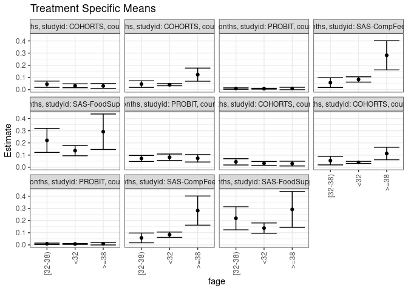

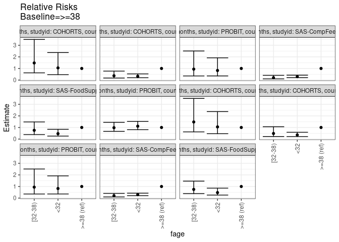

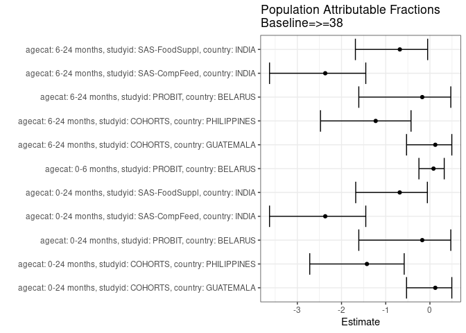

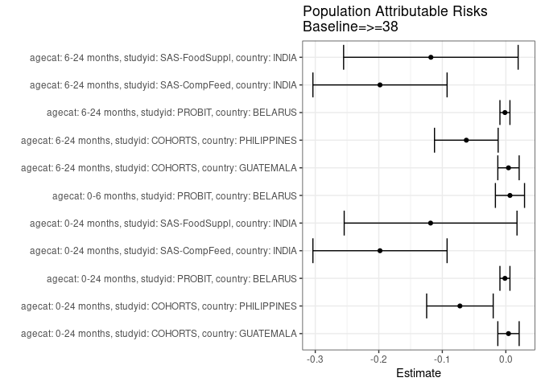

## Results Table

### Parameter: TSM

| agecat | studyid | country | intervention_level | baseline_level | estimate | ci_lower | ci_upper |
| --- | --- | --- | --- | --- | --- | --- | --- |
| 0-24 months | COHORTS | GUATEMALA | >=38 | NA | 0.0302013 | 0.0107608 | 0.0496418 |
| 0-24 months | COHORTS | GUATEMALA | <32 | NA | 0.0317125 | 0.0159128 | 0.0475121 |
| 0-24 months | COHORTS | GUATEMALA | [32-38) | NA | 0.0445344 | 0.0187968 | 0.0702720 |
| 0-24 months | COHORTS | PHILIPPINES | >=38 | NA | 0.1229431 | 0.0691189 | 0.1767674 |
| 0-24 months | COHORTS | PHILIPPINES | <32 | NA | 0.0402817 | 0.0318223 | 0.0487411 |
| 0-24 months | COHORTS | PHILIPPINES | [32-38) | NA | 0.0454615 | 0.0185206 | 0.0724024 |
| 0-24 months | PROBIT | BELARUS | >=38 | NA | 0.0095498 | -0.0004274 | 0.0195270 |
| 0-24 months | PROBIT | BELARUS | <32 | NA | 0.0078912 | 0.0044813 | 0.0113012 |
| 0-24 months | PROBIT | BELARUS | [32-38) | NA | 0.0089980 | 0.0032551 | 0.0147408 |
| 0-24 months | SAS-CompFeed | INDIA | >=38 | NA | 0.2817387 | 0.1620544 | 0.4014230 |
| 0-24 months | SAS-CompFeed | INDIA | <32 | NA | 0.0836778 | 0.0618861 | 0.1054696 |
| 0-24 months | SAS-CompFeed | INDIA | [32-38) | NA | 0.0573737 | 0.0173126 | 0.0974349 |
| 0-24 months | SAS-FoodSuppl | INDIA | >=38 | NA | 0.2917759 | 0.1463202 | 0.4372317 |
| 0-24 months | SAS-FoodSuppl | INDIA | <32 | NA | 0.1363744 | 0.0944466 | 0.1783023 |
| 0-24 months | SAS-FoodSuppl | INDIA | [32-38) | NA | 0.2205827 | 0.1221323 | 0.3190330 |
| 0-6 months | PROBIT | BELARUS | >=38 | NA | 0.0736857 | 0.0431038 | 0.1042676 |
| 0-6 months | PROBIT | BELARUS | <32 | NA | 0.0819107 | 0.0551307 | 0.1086907 |
| 0-6 months | PROBIT | BELARUS | [32-38) | NA | 0.0722558 | 0.0473993 | 0.0971122 |
| 6-24 months | COHORTS | GUATEMALA | >=38 | NA | 0.0302013 | 0.0107608 | 0.0496418 |
| 6-24 months | COHORTS | GUATEMALA | <32 | NA | 0.0317125 | 0.0159128 | 0.0475121 |
| 6-24 months | COHORTS | GUATEMALA | [32-38) | NA | 0.0445344 | 0.0187968 | 0.0702720 |
| 6-24 months | COHORTS | PHILIPPINES | >=38 | NA | 0.1128819 | 0.0614069 | 0.1643569 |
| 6-24 months | COHORTS | PHILIPPINES | <32 | NA | 0.0401254 | 0.0317322 | 0.0485187 |
| 6-24 months | COHORTS | PHILIPPINES | [32-38) | NA | 0.0545437 | 0.0194618 | 0.0896257 |
| 6-24 months | PROBIT | BELARUS | >=38 | NA | 0.0095498 | -0.0004274 | 0.0195270 |
| 6-24 months | PROBIT | BELARUS | <32 | NA | 0.0078912 | 0.0044813 | 0.0113012 |
| 6-24 months | PROBIT | BELARUS | [32-38) | NA | 0.0089980 | 0.0032551 | 0.0147408 |
| 6-24 months | SAS-CompFeed | INDIA | >=38 | NA | 0.2817387 | 0.1620544 | 0.4014230 |
| 6-24 months | SAS-CompFeed | INDIA | <32 | NA | 0.0836778 | 0.0618861 | 0.1054696 |
| 6-24 months | SAS-CompFeed | INDIA | [32-38) | NA | 0.0573737 | 0.0173126 | 0.0974349 |
| 6-24 months | SAS-FoodSuppl | INDIA | >=38 | NA | 0.2913366 | 0.1441283 | 0.4385449 |
| 6-24 months | SAS-FoodSuppl | INDIA | <32 | NA | 0.1378712 | 0.0956961 | 0.1800463 |
| 6-24 months | SAS-FoodSuppl | INDIA | [32-38) | NA | 0.2184079 | 0.1236865 | 0.3131293 |

### Parameter: E(Y)

| agecat | studyid | country | intervention_level | baseline_level | estimate | ci_lower | ci_upper |
| --- | --- | --- | --- | --- | --- | --- | --- |
| 0-24 months | COHORTS | GUATEMALA | NA | NA | 0.0343811 | 0.0231829 | 0.0455794 |
| 0-24 months | COHORTS | PHILIPPINES | NA | NA | 0.0506794 | 0.0424394 | 0.0589194 |
| 0-24 months | PROBIT | BELARUS | NA | NA | 0.0081367 | 0.0045083 | 0.0117651 |
| 0-24 months | SAS-CompFeed | INDIA | NA | NA | 0.0836390 | 0.0602327 | 0.1070453 |
| 0-24 months | SAS-FoodSuppl | INDIA | NA | NA | 0.1733333 | 0.1349698 | 0.2116969 |
| 0-6 months | PROBIT | BELARUS | NA | NA | 0.0801901 | 0.0546922 | 0.1056880 |
| 6-24 months | COHORTS | GUATEMALA | NA | NA | 0.0343811 | 0.0231829 | 0.0455794 |
| 6-24 months | COHORTS | PHILIPPINES | NA | NA | 0.0506794 | 0.0424394 | 0.0589194 |
| 6-24 months | PROBIT | BELARUS | NA | NA | 0.0081367 | 0.0045083 | 0.0117651 |
| 6-24 months | SAS-CompFeed | INDIA | NA | NA | 0.0836390 | 0.0602327 | 0.1070453 |
| 6-24 months | SAS-FoodSuppl | INDIA | NA | NA | 0.1733333 | 0.1349698 | 0.2116969 |

### Parameter: RR

| agecat | studyid | country | intervention_level | baseline_level | estimate | ci_lower | ci_upper |
| --- | --- | --- | --- | --- | --- | --- | --- |
| 0-24 months | COHORTS | GUATEMALA | >=38 | >=38 | 1.0000000 | 1.0000000 | 1.0000000 |
| 0-24 months | COHORTS | GUATEMALA | <32 | >=38 | 1.0500352 | 0.4652609 | 2.3697973 |
| 0-24 months | COHORTS | GUATEMALA | [32-38) | >=38 | 1.4745839 | 0.6208331 | 3.5023869 |
| 0-24 months | COHORTS | PHILIPPINES | >=38 | >=38 | 1.0000000 | 1.0000000 | 1.0000000 |
| 0-24 months | COHORTS | PHILIPPINES | <32 | >=38 | 0.3276449 | 0.2016512 | 0.5323605 |
| 0-24 months | COHORTS | PHILIPPINES | [32-38) | >=38 | 0.3697766 | 0.1769762 | 0.7726166 |
| 0-24 months | PROBIT | BELARUS | >=38 | >=38 | 1.0000000 | 1.0000000 | 1.0000000 |
| 0-24 months | PROBIT | BELARUS | <32 | >=38 | 0.8263257 | 0.3563087 | 1.9163557 |
| 0-24 months | PROBIT | BELARUS | [32-38) | >=38 | 0.9422144 | 0.3541747 | 2.5065823 |
| 0-24 months | SAS-CompFeed | INDIA | >=38 | >=38 | 1.0000000 | 1.0000000 | 1.0000000 |
| 0-24 months | SAS-CompFeed | INDIA | <32 | >=38 | 0.2970052 | 0.2084008 | 0.4232809 |
| 0-24 months | SAS-CompFeed | INDIA | [32-38) | >=38 | 0.2036416 | 0.1020434 | 0.4063948 |
| 0-24 months | SAS-FoodSuppl | INDIA | >=38 | >=38 | 1.0000000 | 1.0000000 | 1.0000000 |
| 0-24 months | SAS-FoodSuppl | INDIA | <32 | >=38 | 0.4673944 | 0.2592486 | 0.8426566 |
| 0-24 months | SAS-FoodSuppl | INDIA | [32-38) | >=38 | 0.7560003 | 0.3866246 | 1.4782721 |
| 0-6 months | PROBIT | BELARUS | >=38 | >=38 | 1.0000000 | 1.0000000 | 1.0000000 |
| 0-6 months | PROBIT | BELARUS | <32 | >=38 | 1.1116227 | 0.8085234 | 1.5283477 |
| 0-6 months | PROBIT | BELARUS | [32-38) | >=38 | 0.9805939 | 0.6655229 | 1.4448253 |
| 6-24 months | COHORTS | GUATEMALA | >=38 | >=38 | 1.0000000 | 1.0000000 | 1.0000000 |
| 6-24 months | COHORTS | GUATEMALA | <32 | >=38 | 1.0500352 | 0.4652609 | 2.3697973 |
| 6-24 months | COHORTS | GUATEMALA | [32-38) | >=38 | 1.4745839 | 0.6208331 | 3.5023869 |
| 6-24 months | COHORTS | PHILIPPINES | >=38 | >=38 | 1.0000000 | 1.0000000 | 1.0000000 |
| 6-24 months | COHORTS | PHILIPPINES | <32 | >=38 | 0.3554637 | 0.2152664 | 0.5869679 |
| 6-24 months | COHORTS | PHILIPPINES | [32-38) | >=38 | 0.4831929 | 0.2196313 | 1.0630336 |
| 6-24 months | PROBIT | BELARUS | >=38 | >=38 | 1.0000000 | 1.0000000 | 1.0000000 |
| 6-24 months | PROBIT | BELARUS | <32 | >=38 | 0.8263257 | 0.3563087 | 1.9163557 |
| 6-24 months | PROBIT | BELARUS | [32-38) | >=38 | 0.9422144 | 0.3541747 | 2.5065823 |
| 6-24 months | SAS-CompFeed | INDIA | >=38 | >=38 | 1.0000000 | 1.0000000 | 1.0000000 |
| 6-24 months | SAS-CompFeed | INDIA | <32 | >=38 | 0.2970052 | 0.2084008 | 0.4232809 |
| 6-24 months | SAS-CompFeed | INDIA | [32-38) | >=38 | 0.2036416 | 0.1020434 | 0.4063948 |
| 6-24 months | SAS-FoodSuppl | INDIA | >=38 | >=38 | 1.0000000 | 1.0000000 | 1.0000000 |
| 6-24 months | SAS-FoodSuppl | INDIA | <32 | >=38 | 0.4732368 | 0.2611839 | 0.8574534 |
| 6-24 months | SAS-FoodSuppl | INDIA | [32-38) | >=38 | 0.7496754 | 0.3843045 | 1.4624166 |

### Parameter: PAR

| agecat | studyid | country | intervention_level | baseline_level | estimate | ci_lower | ci_upper |
| --- | --- | --- | --- | --- | --- | --- | --- |
| 0-24 months | COHORTS | GUATEMALA | >=38 | NA | 0.0041798 | -0.0126151 | 0.0209747 |
| 0-24 months | COHORTS | PHILIPPINES | >=38 | NA | -0.0722637 | -0.1246460 | -0.0198815 |
| 0-24 months | PROBIT | BELARUS | >=38 | NA | -0.0014131 | -0.0092896 | 0.0064634 |
| 0-24 months | SAS-CompFeed | INDIA | >=38 | NA | -0.1980997 | -0.3037206 | -0.0924787 |
| 0-24 months | SAS-FoodSuppl | INDIA | >=38 | NA | -0.1184426 | -0.2544735 | 0.0175883 |
| 0-6 months | PROBIT | BELARUS | >=38 | NA | 0.0065044 | -0.0164292 | 0.0294380 |
| 6-24 months | COHORTS | GUATEMALA | >=38 | NA | 0.0041798 | -0.0126151 | 0.0209747 |
| 6-24 months | COHORTS | PHILIPPINES | >=38 | NA | -0.0622025 | -0.1122980 | -0.0121070 |
| 6-24 months | PROBIT | BELARUS | >=38 | NA | -0.0014131 | -0.0092896 | 0.0064634 |
| 6-24 months | SAS-CompFeed | INDIA | >=38 | NA | -0.1980997 | -0.3037206 | -0.0924787 |
| 6-24 months | SAS-FoodSuppl | INDIA | >=38 | NA | -0.1180033 | -0.2553894 | 0.0193828 |

### Parameter: PAF

| agecat | studyid | country | intervention_level | baseline_level | estimate | ci_lower | ci_upper |
| --- | --- | --- | --- | --- | --- | --- | --- |
| 0-24 months | COHORTS | GUATEMALA | >=38 | NA | 0.1215724 | -0.5292244 | 0.4954076 |
| 0-24 months | COHORTS | PHILIPPINES | >=38 | NA | -1.4258998 | -2.7193510 | -0.5822626 |
| 0-24 months | PROBIT | BELARUS | >=38 | NA | -0.1736698 | -1.6092332 | 0.4720668 |
| 0-24 months | SAS-CompFeed | INDIA | >=38 | NA | -2.3685074 | -3.6291506 | -1.4511716 |
| 0-24 months | SAS-FoodSuppl | INDIA | >=38 | NA | -0.6833226 | -1.6790793 | -0.0576675 |
| 0-6 months | PROBIT | BELARUS | >=38 | NA | 0.0811124 | -0.2486919 | 0.3238088 |
| 6-24 months | COHORTS | GUATEMALA | >=38 | NA | 0.1215724 | -0.5292244 | 0.4954076 |
| 6-24 months | COHORTS | PHILIPPINES | >=38 | NA | -1.2273725 | -2.4757600 | -0.4273679 |
| 6-24 months | PROBIT | BELARUS | >=38 | NA | -0.1736698 | -1.6092332 | 0.4720668 |
| 6-24 months | SAS-CompFeed | INDIA | >=38 | NA | -2.3685074 | -3.6291506 | -1.4511716 |
| 6-24 months | SAS-FoodSuppl | INDIA | >=38 | NA | -0.6807882 | -1.6861027 | -0.0517279 |